# Stretching and Shrinking Functions

# Agenda

- Entrance Ticket: [ET_1001](https://bart.instructure.com/courses/2110/quizzes/3209)
  - When function transformation given as an equation like $y=\ldots f(x\ldots)\ldots$:
    - To get new $x$ values, set argument=$a$, where $a$ is an old $x$ value.
    - To get new $y$ values, replace $f(\ldots)$ with $b$, where $b$ is an old $y$ value.
- [OCW_1001_scaling_descriptions](https://bart.instructure.com/courses/2110/quizzes/3210)
  - Describe the stretching/shrinking shown with equation and graph.
- [OCW_1001_B_stretch_eqs](https://bart.instructure.com/courses/2110/quizzes/3211)
  - From graph, determine the function-stretch equation.

# Stretching/shrinking

Transformations are described relative to $y=f(x)$.

- $y=f(2x)$ causes points to shrink horizontally towards the $y$ axis.
  $$(a,b)\to
  \left(\frac{a}{2}~,~b\right)$$
- $y=f{\left(\frac{x}{2}\right)}$ causes points to stretch horizontally away from the $y$ axis.
  $$(a,b)\to \left(2a~,~b\right)$$
- $y=2\cdot f(x)$ causes points to stretch vertically away from the $x$ axis.
  $$(a,b)\to
  \left(a~,~2b\right)$$
- $y=\frac{f(x)}{2}$ causes points to shrink vertically toward the $x$ axis.
  $$(a,b)\to
  \left(a~,~\frac{b}{2}\right)$$

Of course, I’m just using 2 as an example. This generalizes with any scale factor.

- The horizontal transformations are “backwards” and indicated by operations inside the argument.
- The vertical transformations are “normal” and indicated by operations outside the function.

# Examples of horizontal shrinking

Notice $y=\sqrt{2x}$ is shrunk towards the $y$ axis. (Unfortunately we see this could also be visualized as a stretch vertically. A lot of the parent functions have an equivalent vertical stretch for any horiztonal shrink.)

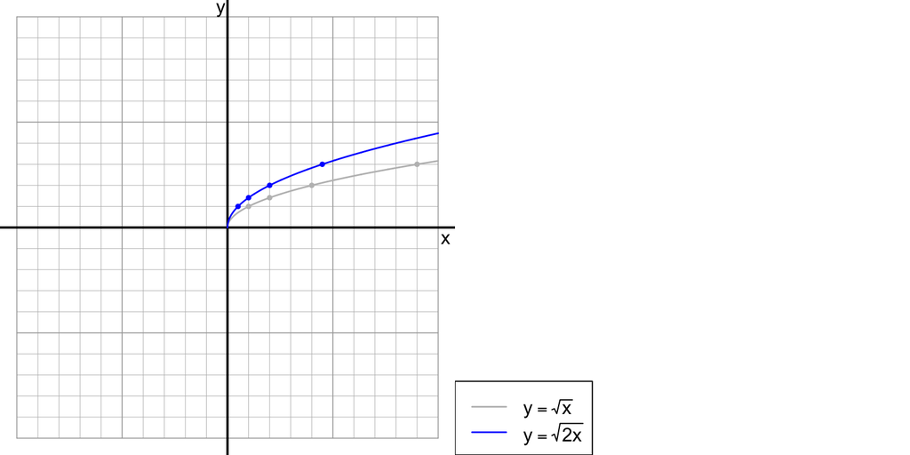

Notice $y=\cos(2x)$ is shrunk towards the $y$ axis. The trigonometric wave functions are excellent examples of functions with clearly distinct horizontal shrink and vertical stretch.

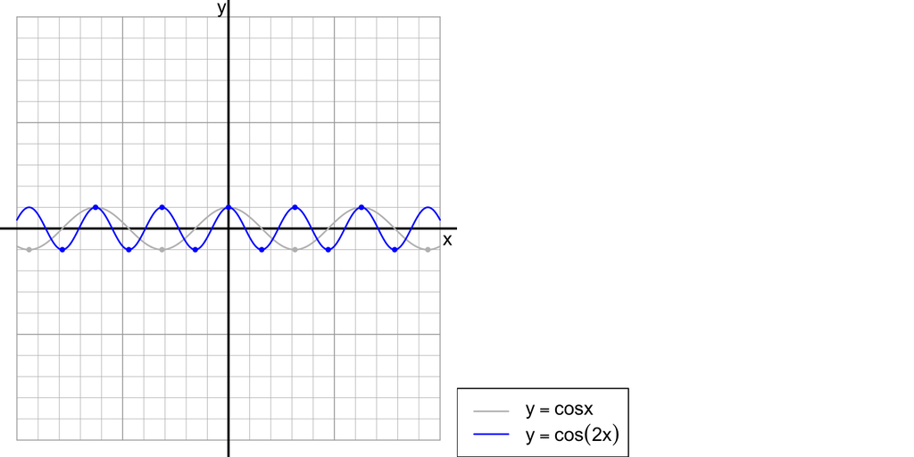

# Example of horizontal stretch

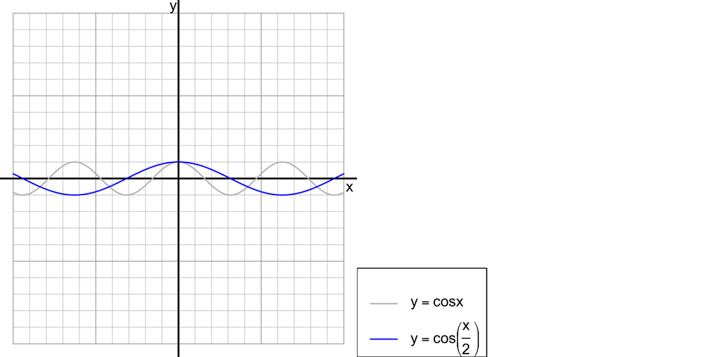

# Example of vertical stretch

Notice $y=2\cos(x)$ is stretched away from the $x$ axis.

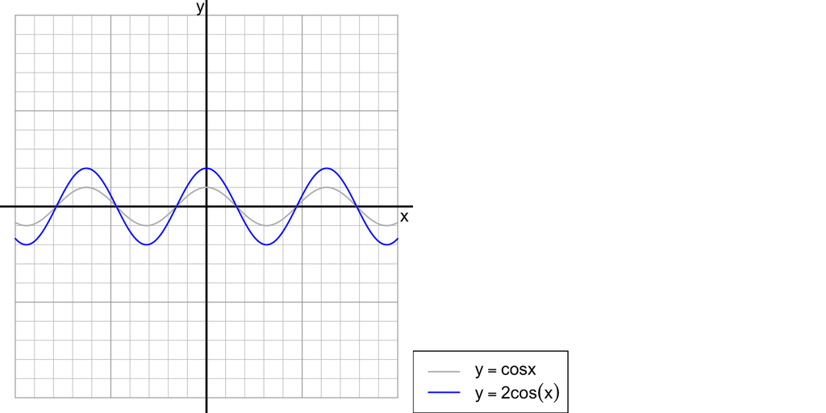

# Example of vertical shrink

Notice $y=\frac{\cos(x)}{2}$ is shrunk toward the $x$ axis.

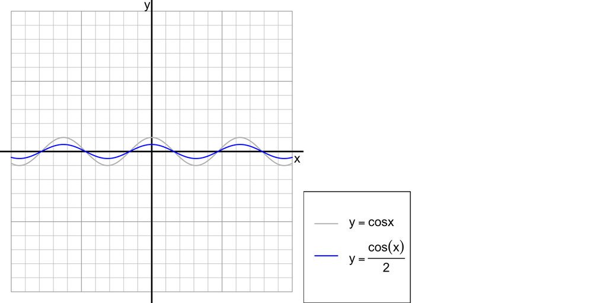